# ①（Pythonを使えるようになろう）

# Lesson1

# Anacondaのインストール

1. インストール方法
   1. 説明してるっぽいページ  
      https://www.python.jp/install/anaconda/windows/install.html
   2. インストールするページ  
      https://www.anaconda.com/products/individual

# Jupyter Notebookの使い方

1. ソースの書き方  
   口頭説明
2. Markdownへの切り替え方  
   口頭説明
3. .htmlファイルの書き出し方法  
   口頭説明

# Lesson2

### Sample1.py

```python
#画面に出力する
print("私の名前は工藤健吾")
print("Pythonでほげほげしよう")
```

```
私の名前は工藤健吾
Pythonでほげほげしよう
```

```python
print("えるしってるか。くどうはらーめん\
（二郎系）しかたべない")
```

```
えるしってるか。くどうはらーめん（二郎系）しかたべない
```

### 構文（画面に出力する）

```
print(・・・)
```

## 数値リテラル

・整数リテラル  
・浮動小数点リテラル  
・虚数リテラル

リテラルは""で囲わないらしいよ

### Sample2.py

```python
print(1)
print(3.14)
```

```
1
3.14
```

## 進数表現

・二進数 0b  
・八進数 0o  
・十六進数 0x

### Sample3.py

```python
print("10進数の10は", 10, "です。")
print("2進数の10は", 0b10, "です。")
print("8進数の10は", 0o10, "です。")
print("16進数の10は", 0x10, "です。")
print("16進数のFは", 0xF, "です。")
```

```
10進数の10は 10 です。
2進数の10は 2 です。
8進数の10は 8 です。
16進数の10は 16 です。
16進数のFは 15 です。
```

## エスケープシーケンス

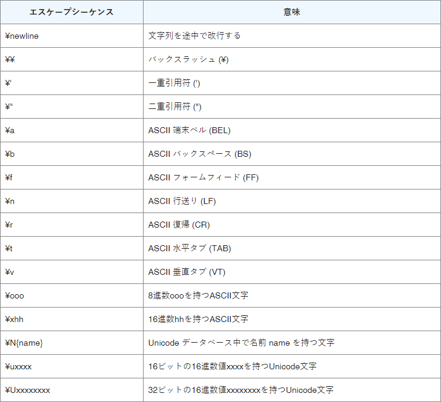

### Sample4.py

```python
print("円記号を表示します。:\\")
print("アポストロフィを表示します。:\'")
```

```
円記号を表示します。:\
アポストロフィを表示します。:'
```

# ほげ要望(^ω^)

教科書:レッスンのまとめ  
・lesson1  
・lesson2  
練習をやってくれたら喜びます

# エクストラほげ問題①

## 高校数学Ⅱ 整式の微分

## 極限値の計算、平均変化率、導関数の定義

人工知能（AI）を学ぶ上で必須な数学の知識を問うような問題を出します。  
最低限の内容ばかり問うのでわからない人は焦った方がいいと思います（ほげおくん調べ）

### もんだいだよん(^ω^)

次の極限値を求めよ  
①$\lim_{x \to 0} (2x + 1)$

②関数 $y = x^2$ において， $x$ の値が 1 から 2 まで変化するときの平均変化率を求めなさい

次の関数を導関数の定義にしたがって，微分しなさい

③$f(x) = 3x^2$

④$y = x^3$

⑤$f(x) = \frac{3}{x}$

# エクストラがんばれ問題（がんばれ）

点数のためにもがんばってね  
エクストラ問題っぽいやつに加えて、 Javaでもやった変数、四則演算、forループとif文を先にやっちゃうよ  
問題3はできたらすごいよ

```python
# 問題1
# 下の出力からスペースを消して出力して下さい

print("スペース","を","消したい")

# 出力例：スペースを消したい
```

```
スペース を 消したい
```

```python
# 問題2
# numという変数は使ったままでスペースを使って出力してください

num = 2
print("スペースを",num,"つ消したい")

# 出力例：スペースを2つ消したい
```

```
スペースを 2 つ消したい
```

```python
#問題3
#forループとif文をつかってy=x/3のグラフっぽいやつ書いてみよう
#10×10より大きいサイズで
#どこ書き換えてもいいよ

for y in range(20):
    for x in range(40):
        if(y==x*3):
            print("●",end="")
        else:
            print("〇",end="")
    print()
```

```
●〇〇〇〇〇〇〇〇〇〇〇〇〇〇〇〇〇〇〇〇〇〇〇〇〇〇〇〇〇〇〇〇〇〇〇〇〇〇〇
〇〇〇〇〇〇〇〇〇〇〇〇〇〇〇〇〇〇〇〇〇〇〇〇〇〇〇〇〇〇〇〇〇〇〇〇〇〇〇〇
〇〇〇〇〇〇〇〇〇〇〇〇〇〇〇〇〇〇〇〇〇〇〇〇〇〇〇〇〇〇〇〇〇〇〇〇〇〇〇〇
〇●〇〇〇〇〇〇〇〇〇〇〇〇〇〇〇〇〇〇〇〇〇〇〇〇〇〇〇〇〇〇〇〇〇〇〇〇〇〇
〇〇〇〇〇〇〇〇〇〇〇〇〇〇〇〇〇〇〇〇〇〇〇〇〇〇〇〇〇〇〇〇〇〇〇〇〇〇〇〇
〇〇〇〇〇〇〇〇〇〇〇〇〇〇〇〇〇〇〇〇〇〇〇〇〇〇〇〇〇〇〇〇〇〇〇〇〇〇〇〇
〇〇●〇〇〇〇〇〇〇〇〇〇〇〇〇〇〇〇〇〇〇〇〇〇〇〇〇〇〇〇〇〇〇〇〇〇〇〇〇
〇〇〇〇〇〇〇〇〇〇〇〇〇〇〇〇〇〇〇〇〇〇〇〇〇〇〇〇〇〇〇〇〇〇〇〇〇〇〇〇
〇〇〇〇〇〇〇〇〇〇〇〇〇〇〇〇〇〇〇〇〇〇〇〇〇〇〇〇〇〇〇〇〇〇〇〇〇〇〇〇
〇〇〇●〇〇〇〇〇〇〇〇〇〇〇〇〇〇〇〇〇〇〇〇〇〇〇〇〇〇〇〇〇〇〇〇〇〇〇〇
〇〇〇〇〇〇〇〇〇〇〇〇〇〇〇〇〇〇〇〇〇〇〇〇〇〇〇〇〇〇〇〇〇〇〇〇〇〇〇〇
〇〇〇〇〇〇〇〇〇〇〇〇〇〇〇〇〇〇〇〇〇〇〇〇〇〇〇〇〇〇〇〇〇〇〇〇〇〇〇〇
〇〇〇〇●〇〇〇〇〇〇〇〇〇〇〇〇〇〇〇〇〇〇〇〇〇〇〇〇〇〇〇〇〇〇〇〇〇〇〇
〇〇〇〇〇〇〇〇〇〇〇〇〇〇〇〇〇〇〇〇〇〇〇〇〇〇〇〇〇〇〇〇〇〇〇〇〇〇〇〇
〇〇〇〇〇〇〇〇〇〇〇〇〇〇〇〇〇〇〇〇〇〇〇〇〇〇〇〇〇〇〇〇〇〇〇〇〇〇〇〇
〇〇〇〇〇●〇〇〇〇〇〇〇〇〇〇〇〇〇〇〇〇〇〇〇〇〇〇〇〇〇〇〇〇〇〇〇〇〇〇
〇〇〇〇〇〇〇〇〇〇〇〇〇〇〇〇〇〇〇〇〇〇〇〇〇〇〇〇〇〇〇〇〇〇〇〇〇〇〇〇
〇〇〇〇〇〇〇〇〇〇〇〇〇〇〇〇〇〇〇〇〇〇〇〇〇〇〇〇〇〇〇〇〇〇〇〇〇〇〇〇
〇〇〇〇〇〇●〇〇〇〇〇〇〇〇〇〇〇〇〇〇〇〇〇〇〇〇〇〇〇〇〇〇〇〇〇〇〇〇〇
〇〇〇〇〇〇〇〇〇〇〇〇〇〇〇〇〇〇〇〇〇〇〇〇〇〇〇〇〇〇〇〇〇〇〇〇〇〇〇〇
```

# えくすとらぽむぽむ問題（天使の様なやさしさッ）

python楽しいって思ってくれたらうれしーです by お嬢

```python
##まず実行してみてね
sample = input()
```

```
hoge
```

## 先輩に自己紹介してみよう

以下実行結果  
あなたの名前を教えてねみかみれいな  
好きな曲を教えてねBADLOVE  
みかみれいなはBADLOVEが好きです

```python
#（）の中を追加するだけで完成させてね
# 実行するときはあなたのことを書いてください★

name = input()

song = input()

print(name,song)
```

```
hoge
fuga
hoge fuga
```

## ちょっと頑張って好きな数字を答えてみよう

以下実行結果  
好きな数字は？  
あなたの好きな数字は25です

※数字以外を入力した場合、"エラー：数字で入力してください"が出力するようにする

```python
# ★の部分だけをかいて完成させてね

# １回目にあなたの好きな数字を入力したパターン
# 2回目に工藤先生と入力したパターンでやってね
for i in range(2):
    try:
        number = #★
    #★
        print("エラー：数字で入力してください")
    #★
        print("あなたの好きな数字は",number,"です")
```

```
  File "<ipython-input-11-30cc25c9faee>", line 7
    number = #★
               ^
SyntaxError: invalid syntax
```